# 浅野ゼミナール 春合宿 2019

2019年5月11日から12日にかけて、栃木県日光市鬼怒川温泉にて2019年度浅野ゼミナール春合宿が行われました。今回のゼミ合宿では、浅野教授をはじめ2年生から4年生まで計33名が参加し、親睦を深めることができました。

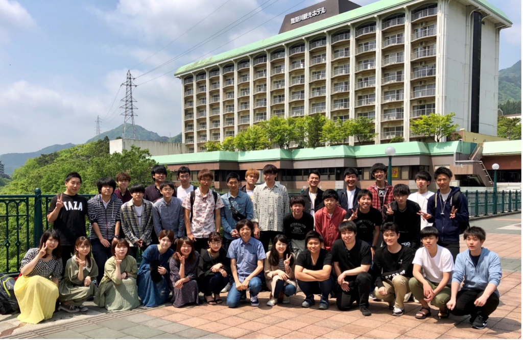

鬼怒川温泉での記念撮影

鬼怒川温泉までは豊かな自然や美しい田園風景、そして冷たく澄んだ空気を感じながら電車で行きました。電車内では、学年を超えて様々な話題で盛り上がり、学年の垣根を越えて親睦をを深めることができました。私は鬼怒川温泉駅に到着するや否や、駅前にあった足湯に直行し、早速、温泉を満喫しました。お湯加減がちょうどよく、とても気持ちよかったです。お肌がすべすべになりました。宿泊先である鬼怒川温泉観光ホテルに到着後、2年生から4年生まで、ゼミ生同士の顔合わせを兼ねて、一人一人自己紹介をしました。ゼミ生それぞれの個性が強く、面白いと感じました。その後は、夕食の時間まで各自自由に過ごしました。鬼怒川温泉に来たということもあり、温泉を楽しんだり、部屋でUNOやトランプをして楽しむ学生もいました。

[figure not shown]

電車内の様子

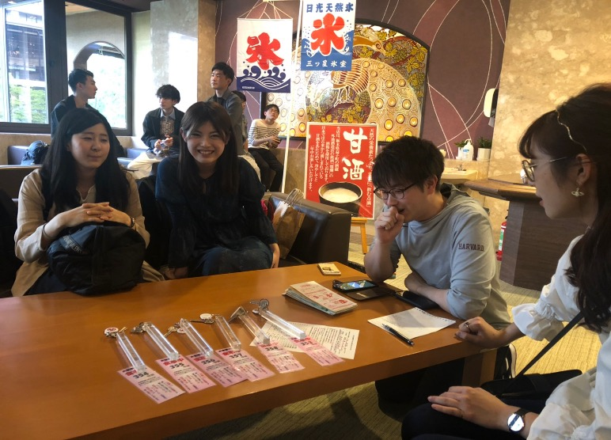

部屋割りをする合宿幹事の皆さん

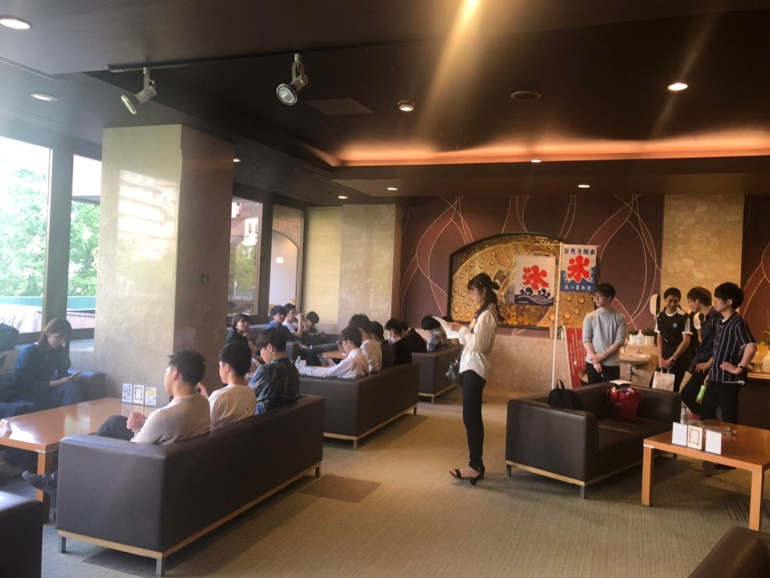

自己紹介の様子

夕食は、ホテルの絶品料理でとても美味しかったです。夕食では普段話したこのないゼミ生達と学年を超えて話をする機会を得ることができました。夕食後、毎年恒例の豪華景品を狙って先輩後輩が競い合う壮絶なビンゴ大会が行われました。複数のビンゴが出る度にじゃんけんによって勝者を決めるガチンコバトルが繰り広げられました。ここでもより一層仲良くなることができました。その後、温泉に入り1日を終えました。

[figure not shown]

夕食の様子

[figure not shown]

翌朝、朝食を済ませてから合宿施設の近くの橋の上で集合写真を撮りました。合宿が終わる頃にはゼミ内の交流が深まったようで、今後のゼミ活動や夏合宿に向けて良いスタートが切れたと思います。今回の春合宿を企画して下さった幹事の方々に感謝いたします。 （文責：政経学部 法律政治学科 ３年 関駿介）

### ゼミ生の感想

#### 政経学部 法律政治学科 ２年 平林真奈

今回、春合宿に参加し、たくさんの思い出を作ることができました。先輩方とはまだあまり交流がなく緊張していましたが、たくさん話しかけていただき、とてもうれしかったです。同級生ともこの二日間でより仲良くなることができ、これからのゼミの時間が楽しみになりました。先生や先輩、同級生もみんながやさしく、とても良いゼミに入ることができたと心から思いました。

#### 政経学部 経済学科 ３年 下ノ村祐真

私はまだ浅野ゼミに参加して間もないため、少し不安でしたが、無事に過ごすことができました。宴会やビンゴ大会、自由時間での交流などで3・4年生の皆さんや、まだ会ったことのなかった2年生とも仲良くなれて嬉しかったです。これからもよろしくお願いします。

#### 政経学部 法律政治学科 4年 滝瀬友優貴

とても有意義な春合宿でした。企画してくれた幹事をはじめ３年生の皆さんに感謝します。本当にありがとうございました。春合宿を通じて、ゼミ生とコミュニケーションを取れ交流できたことは、これからより充実したゼミナール活動を行うための良いきっかけになったと思います。